# Week 02 - Social Network Analysis

- Show All Code
- Hide All Code

Network representations and basic manipulations in R

Welcome to the second session of the seminar **Computational Social Sciences**

```r
library(needs)
needs(igraph,
      ggraph,
      ggplot2,
      patchwork)

# Set seed for reproducibility
set.seed(123)
```

# Social networks

A **social network** consists of a set of **actors** that are connected by **relationships** in a pairwise manner (Wasserman and Faust 2009). Actors can represent individuals, groups, organizations, companies, or even entire countries. The nature of these relationships varies and can be defined in different ways, such as:

- **Similarity-based relationships** (e.g., shared interests, attributes, or behaviors)
- **Role- and position-based relationships** (e.g., hierarchies, affiliations, or professional connections)
- **Resource-transfer relationships** (e.g., exchange of information, goods, or support)

Networks are commonly visualized in plots by **nodes** (usually circles), representing the actors and **edges** (lines or arrows) , representing the relationships.

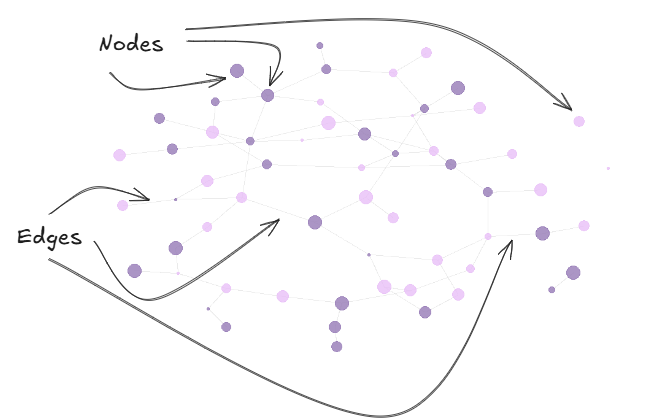

Social network with nodes and edges

```r
# Generate a random graph with 30 nodes and 50 edges
g <- sample_gnm(n = 60, m = 70, directed = FALSE)

# Assign random colors to nodes
V(g)$color <- sample(c("blue", "green"), vcount(g), replace = TRUE)

# Assign random sizes to nodes
V(g)$size <- sample(5:12, vcount(g), replace = TRUE)

  # Plot the network using ggraph
p1 <-ggraph(g, layout = "fr") +
      geom_edge_link(color = "gray", alpha = 0.5) +
      geom_node_point(aes(size = size, color = color), alpha = 0.8) +
      scale_color_manual(values = c("blue" = "#967bb6", "green" = "#e8bff7")) +
      theme_void() +
      theme(legend.position = "none")

plot(p1)
```

# Social Network Analysis

In the context of social network analysis from a sociological perspective, we typically discuss two broad aspects.

One of these aspects revolves around **network theories**, which explore how individuals behave within social contexts and how networks themselves evolve and function. Central questions in this area include: Where do network relationships originate? How are they formed? And what are the implications and consequences of these relationships for the people involved (Lizardo and Isaac Jilbert 2023)

## Exercise

Reflect briefly on the occasions, where in the past you have been confronted with social networks theories. In what theoretical concepts of sociology is the embedding of actors of central importance?

The other big branch focuses mostly on the description of networks and on how to measure various network properties. It links social network contexts to a quantitative representation.

In this class we will try to have a look at both “faces” of social network analysis. We will learn some of the basic concepts and how they connect to measurable network properties.

## From ties to graphs

Imagine you were to plot all relationships of all people in the world. Of course, this is just not possible, as the measurement but also the representation would be too complex. Thus we need some kind of (theoretical) bounds, that make the analysis of networks possible.

In social network analysis, we use **graphs** to represent social networks. We borrow graphs from the mathematical **graph theory** which also provides us with a definition (Joshi 2017).

A **graph** $G$ consists of a vertex set $V$ and an **edge set** $E$:

$$G = \{V, E\}$$

where $V$ is a set of nodes $V=\{v_1,v_2,v_3\}$ and $E$ being a set of edges $E = \{\{v_1,v_2\},\{v_2,v_3\}\}$.

By using set theory, we can rigorously define different types of graphs, operations on graphs, and concepts like **subgraphs, neighbourhoods, or connectivity**.

**Short Digression: Set Theory**

**Sets** are collections of distinct **elements**. The order and repitition of elements in a set does not matter.

| Symbol | Usage | Interpretation in Graphs |
| --- | --- | --- |
| $\emptyset$ | $\{\}$ | Empty set (e.g., a graph with no edges) |
| $\cup$ | $A \cup B$ | Union of sets (e.g., merging vertex or edge sets) |
| $\cap$ | $A \cap B$ | Intersection of sets (e.g., common neighbors) |
| $\setminus$ | $A \setminus B$ | Set difference (e.g., removing edges or vertices) |
| $\times$ | $A \times B$ | Cartesian product (e.g., possible edge pairs in a complete graph) |
| $\mathfrak{P}()$ | $\mathfrak{P}(A)$ | Power set (e.g., all possible subsets of vertices or edges) |
| $\subset$ | $A \subset B$ | Subset (e.g., a subgraph is a subset of a larger graph) |
| $\in$ | $x \in A$ | Element in a set (e.g., a vertex in a vertex set) |
| $\notin$ | $x \notin A$ | Element not in a set (e.g., a missing edge in a sparse graph) |

## Types of graphs

In social network analysis, we distinguish between **directed** and **undirected** networks. In most real-world cases, **directed networks** are more realistic because relationships are often asymmetric. However, **undirected networks** are easier to analyze mathematically and computationally.

#### Directed Networks

Directed networks represent relationships where the connection has a defined direction. These relationships do not necessarily have to be reciprocal.

$$\forall A,B \in V:(A \to B) \not\Rightarrow (B \to A)$$

**Examples:**  
- **Social media interactions**: On Twitter or Instagram, one user can follow another without being followed back.  
- **Communication networks**: E-Mails, phone calls or other forms of communication, can be sent out or received, thus defining a direction.

**Note**: In a **directed graph**, the edges are **ordered**, meaning the edge ( (a, b) ) is **not** the same as ( (b, a) ). The direction of the edge matters, and there is a one-way connection from ( a ) to ( b ) (but not necessarily the other way around).

Edges in directed graphs are thus representations of ordered pairs (**tuples**). We can write these as $E = \{(a,b), (b, c), (c, d), (d, a)\}$.

#### Undirected Networks

Undirected networks assume that if a connection exists, it is inherently mutual. These networks are simpler to analyze since they do not require considering directionality.

$$\forall A, B \in V: (A \leftrightarrow B) \Rightarrow (B \leftrightarrow A)$$

**Examples:**  
- **Mutual friendships**: In many studies, friendship networks are assumed to be undirected, meaning if A considers B a friend, B also considers A a friend (although this is not always the case in reality).  
- **Co-authorship networks**: If two researchers have co-authored a paper together, the connection exists for both equally.  
- **Collaboration networks**: In corporate or scientific collaborations, individuals or institutions work together on projects, making the relationship inherently bidirectional. - **Classmates**

**Note**: In an **undirected graph**, the edges are **unordered**, meaning the edge ( {a, b} ) is the same as ( {b, a} ). The connection between ( a ) and ( b ) has no direction, and this is reflected by the use of **unordered pairs** in the edge set.

In practice, the choice between directed and undirected networks depends on the research question. If directionality is crucial (e.g., influence, hierarchy, or information flow), a **directed network** is necessary. However, if the goal is to analyze overall connectivity, **undirected networks** provide a simpler approach.

```r
# Generate a random graph with 30 nodes and 50 edges
g2 <- sample_gnm(n = 60, m = 70,  directed = TRUE)

# Assign random colors to nodes
V(g2)$color <- sample(c("blue", "green"), vcount(g2), replace = TRUE)

# Assign random sizes to nodes
V(g2)$size <- sample(5:12, vcount(g2), replace = TRUE)

  # Plot the network using ggraph
p1 <- ggraph(g, layout = "fr") +
      geom_edge_link(color = "gray", alpha = 0.5) +
      geom_node_point(aes(size = size, color = color), alpha = 0.8) +
      scale_color_manual(values = c("blue" = "#967bb6", "green" = "#e8bff7")) +
      theme_void() +
      theme(legend.position = "none") +
      ggtitle("Undirected Network")

# Create the directed network plot
p2 <- ggraph(g2, layout = "fr") +
  geom_edge_link(arrow = arrow(length = unit(1.8, "mm"), type = "closed"), color = "gray", alpha = 0.3) +
  geom_node_point(aes(size = size, color = color), alpha = 0.8) +
  scale_color_manual(values = c("blue" = "#967bb6", "green" = "#e8bff7")) +
  theme_void() +
  theme(legend.position = "none") +
  ggtitle("Directed Network")

# Combine the plots
combined_plot <- p1 + p2

# Save as PNG
ggsave("Graphics/undirected_directed.png", plot = combined_plot, width = 15, height = 6, dpi = 300)
```

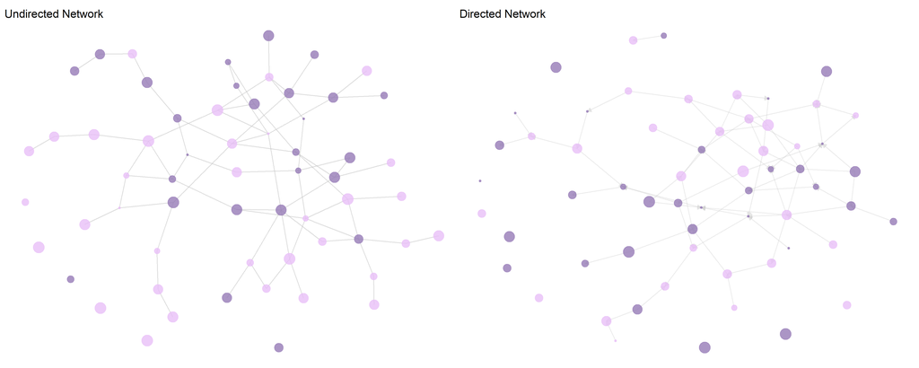

## Network representations

In academic research, networks are often represented as graphs. For small datasets, this visualization is quite intuitive. A quick glance at such a diagram can give us a good sense of the network’s structure.

However, as networks grow larger, this representation quickly reaches its limits. With hundreds, thousands, or even millions of nodes and edges, we end up with what network analysts call a “hairball”—a dense, tangled structure from which little insight can be gained.

This is why, alongside graphical representations, there are other, mathematically more powerful approaches. While they may seem less intuitive, they allows for precise calculations and the analysis of large networks. While graphs help us visually grasp networks, **matrices** or **edge lists** serve as the essential tools for conducting complex computations in network analysis.

#### Adjacency matrices

**Adjacency**: We say that two vertices $v$ and $w$ of a graph $G$ are adjacent if there is an edge joining them, and the vertices v and w are then incident with such an edge. Similarly, two distinct edges $e$ and $f$ are adjacent if they have a vertex in common (Wilson 2009).

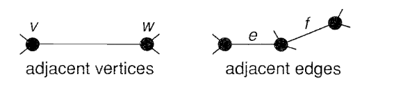

Adjacency

To analyze large networks effectively, we often use **adjacency matrices**. An adjacency matrix $A$ is a square matrix used to represent a finite graph. Each row and column correspond to a node in a network. The entries of the matrix indicate whether a connection exists between two nodes.

In the simplest form, the matrix contains binary values:

$$A = (A_{ij})_{i,j \in V},\text{ where }
A_{ij} =
\begin{cases}
1, & \text{if there is an edge between node } i \text{ and node } j \\
0, & \text{otherwise}
\end{cases}$$

**Diagonal elements:** $A_{ii}$ is typically 0 because a node is not connected to itself.

For an **undirected graph**, the adjacency matrix is **symmetric**, meaning $A_{ij} = A_{ji}$. In contrast, for a **directed graph**, the matrix is generally **asymmetric**, where $A_{ij} = 1$ indicates a directed edge from node $i$ to node $j$, but not necessarily vice versa.

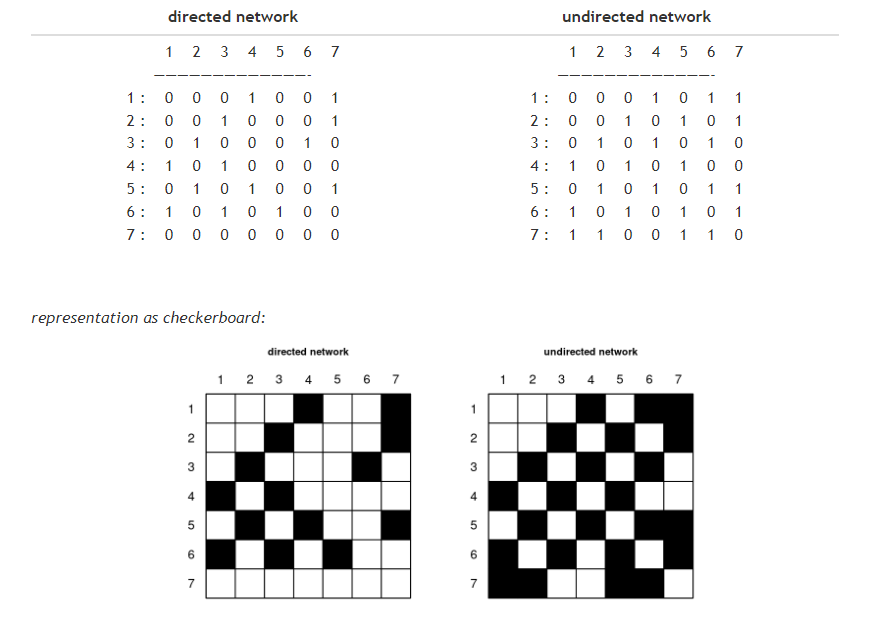

Representation as adjacency matrices

By using different values than 0 and 1 in $A$ , we can also represent a weight of a connection (e.g strength of a friendship, the frequency of interaction or any other meaningful measure of connection intensity).

#### Adjacency lists

Similiarly to the adjacency matrix a adjacency list stores the information if one node in a graph is connected to another, while being a lot more space efficient.

An adjacency list is a collection of lists, where each node has a list of its neighbours.

We can convert from an adjacency matrix to a adjacency list in the way that we iterate over the matrix $A$ and for each entry $A_{ij} = 1$, we add node $j$ to the adjacency list of node $i$.

[output not shown]

#### Edge lists

With even bigger networks it might be useful to even store networks in an edge list, where each edge is represented as a pair (or triplet in weighted graphs) indicating a connection between two nodes.

[output not shown]

**Tip:**

- Use an adjacency matrix if you need fast edge lookups.
- Use an adjacency list for efficient traversal in sparse graphs.
- Use an edge list when edges are dynamic or when importing/exporting graph data.

# Getting started in R

## Creating `igraph` objects

In `igraph` (Csárdi et al. 2025), a network object is an instance of the class *igraph*. There are multiple ways to create such an object, depending on the available data format:

- `graph_from_literal()`: Allows for quick creation of small graphs using a formula-like syntax.
- `graph_from_adj_list()`: Generates a graph from an adjacency list.
- `graph_from_edgelist()`: Constructs a graph from an edgelist.
- `graph_from_adjacency_matrix()`: Builds a graph from an adjacency matrix.
- `read_graph()`:Reads graphs from various file formats, including GraphML and Pajek.
- `graph_from_data_frame()`: Creates a graph from data frames containing edge lists and optional vertex attributes. This is the preferred method for importing tabular data.

### Creating a graph from an adjacency matrix

**Directed graph**:

```r
M <- matrix(c( 0, 1, 0, 0, 0,
               0, 0, 1, 0, 0,
               1, 1, 0, 0, 1,
               0, 1, 0, 0, 0,
               0, 1, 1, 0, 0), nrow = 5, byrow=TRUE)

g <- graph_from_adjacency_matrix(M, mode = "directed")

# Graph descriptives
summary(g)

V(g)  # List nodes
E(g)  # List edges

as_edgelist(g)  # Convert to edge list
as_adjacency_matrix(g) # Get adjacency matrix
as_adj_list(g, mode = "out") # Get adjacency list

vcount(g)  # Count vertices
ecount(g)  # Count edges

# Plot the graph
plot(g)
```

**Undirected graph**:

```r
ug <- graph_from_adjacency_matrix(M, mode = "undirected")
ug
summary(ug)

V(ug)
E(ug)

as_edgelist(ug)
as_adjacency_matrix(ug)
as_adj_list(ug, mode = "out")

vcount(ug)
ecount(ug)

plot(ug)
```

**Accessing the Adjacency matrix**

```r
as_adjacency_matrix(g)  # Retrieve adjacency matrix
g[]  # Print entire adjacency matrix
g[2,1]  # Check if an edge exists from node 2 to 1
g[1,2]  # Check edge from node 1 to 2
g[2,]   # Get all edges originating from node 2
sum(g[2,])  # Count outgoing connections from node 2
```

### Creating a graph from an edge list

```r
edgelist <- rbind(c(1,2), c(1,3), c(2,3), c(2,4), c(3,2), c(5,3))
h <- graph_from_edgelist(edgelist)

plot(h)
```

### Creating a graph from Formula

```r
g <- graph_from_literal(1--2, 2--3, 3--5, 4--2, 1--3, 2--5)

plot(g)

# for directed networks
gd <- graph_from_literal(1-+2, 2-+3, 3-+4, 4++1)

plot(gd)
```

## Adding node and edge attributes

Just the network itself does not hold a lot of information to analyze. In order to sensefully do so on a micro-level, we can add more data to our nodes and edges.

| Category | Example Values |
| --- | --- |
| Nodes | (1,2,3,4) |
| Edges | {(1,2), (2,3), (2,4)} |
| Node attributes | Gender, Age, Income, Status |
| Edge attributes | Strength, Valence (positive, negative), Frequency |
| Metadata | Directed, loops, etc. |

```r
# Assign names to nodes
V(g)$name <- c("Berta", "B", "C", "D", "E")

plot(g)


E(g)$weight <- c(1.2, 2.3, 1.8, 3.0, 2.1, 1.5, 6.3, 8.3)

plot(g, edge.width = E(g)$weight)  # Visualizing edge weights
```

# Notions for network description

The language of graph theory is not standard - lots of authors have their own terminology. Some use the term ‘graph’ for what we call a simple graph, or for a graph with directed edges, or for a graph with infinitely many vertices or edges. In this case the notion is taken from (Wilson 2009).

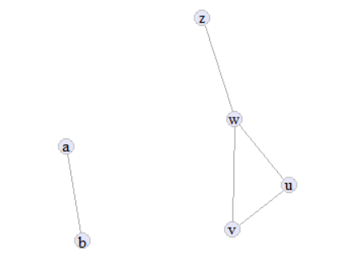

Example of a simple graph

```r
G <- graph_from_literal(v--w, u--w, v--u, u--w, w--z, a --b)

plot(G,
     vertex.color="lavender",
     vertex.frame.color="gray",
     vertex.label.color="black"
     )
```

## Complete graphs and density

Consider this simple graph $G$ with:

- $V(G) = \{w, v, u, z, a, b\}$
- $E(G) = \{ \{v,w\}, \{v,u\}, \{u,w\}, \{w,z\}, \{a,b\}$

A **connected graph** is a graph where there exists a path between any two vertices.

A **disconnected graph** has multiple **components**, meaning some vertices are not reachable from others.

```r
is_connected(karate)
```

A **complete graph** $K_n$ is a simple graph where each pair of distinct vertices is connected by an edge. It has:

$$|E(K_n)| = \frac{n(n-1)}{2}$$

edges.

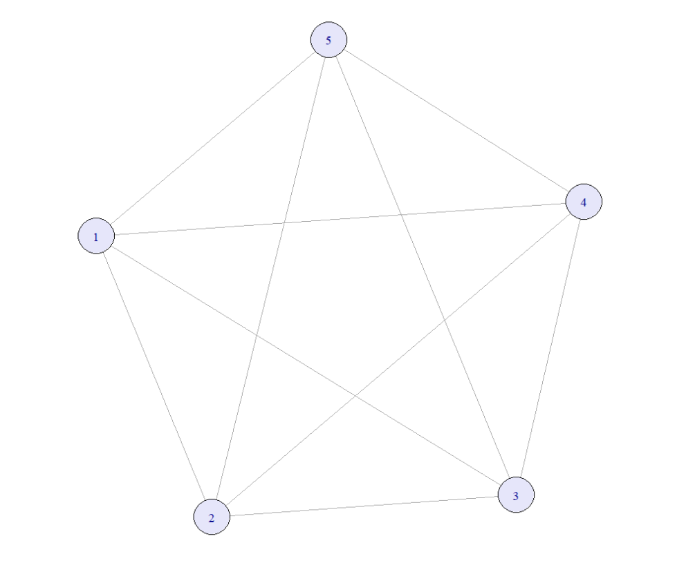

Complete graph

```r
g_complete <- make_full_graph(5)
plot(g_complete,
     vertex.color = "lavender")
```

- The **density** of a graph is a measure of how close it is to being completely connected.

```r
edge_density(make_empty_graph(20))
edge_density(make_full_graph(20))
```

$1 =$ completely connected

$0 =$ completely disconnected

## Paths and Distance

Given an undirected Network $(V, E)$ a **path** of length $l$ is a non-empty sequence of vertices $(v_1, v_2,..., v_{l+1})$, such that $v_i \in V, \forall i = 1,...,l+1$ and $v_i, v_{i+1} \in E \forall i = 1,...,l$ .

- A path is *simple* if $v_1 \neq v_j$ for all $i<j$
- A path is *closed* if $v_1 = v_{i+1}$
- A path is a *cyle* if it is closed and $v_1 \neq v_j$ for all $i<j$, except for the pair $(i,j) = (1, l+1)$
- A *shortest path* between two nodes is also called **geodesic**.

The (following) [Zachary Karate Club](https://en.wikipedia.org/wiki/Zachary%27s_karate_club) data set is a very famous one, as it is publicly available and a good example for small-scale community structure analysis. Check Wikipedia for more information.

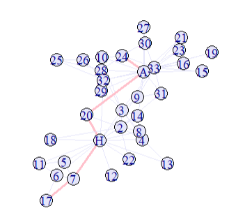

Shortest path between vertice 24 and vertice 17 in the karate network

```r
data(karate)


plot(karate)

sp <- shortest_paths(karate, 17)
sp$vpath[[24]]
path <- E(karate, path=sp$vpath[[24]])

# Set default colors and sizes
V(karate)$color <- "lavender"
E(karate)$color <- "lavender"
E(karate)$width <- 1

# Highlight path in pink
E(karate)[path]$color <- "pink"
E(karate)[path]$width <- 3

# Final plot
plot(karate)
```

- the *distance* $d(i,j)$ between two nodes $i$ and $j$ is the length of the shortest path between them

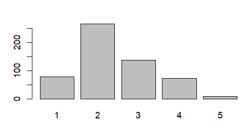

Distance distribution in karate-network

```r
dist <- distances(karate)
dist
dist[1,] #expecting distances from node 1

E(karate)$weight # check the weightes in the network

dist <- distances(karate,
                  weights = rep(1,
                                ecount(karate)
                                )
                  ) #set weigths to 1
dist[1,]

distance_table(karate)
dist_tbl <- distance_table(karate)$res

barplot(dist_tbl,
        names.arg=1:length(dist_tbl)
        )
```

In undirected graphs the distance from node $i$ to node $j$ is the same as from $j$ to $i$. In directed graphs $d(i,j)$ may not be equal $d(j,i)$ and in some pairs even not reachable from one another.

- the *average distance*:

$$\bar{d} = \frac{1}{n(n-1)} \sum_{\substack{i,j = 1 \\ i \ne j}}^{n} d(i, j)$$

```r
mean_distance(karate)
```

[1] 5.754011

If the graph is disconnected, certain node pairs have no connecting path, leading to infinite distances. In such cases, the average is typically computed over all reachable pairs to avoid skewing the result

- the maximum distance between any pair of nodes in the graph is called a **diameter**

$$\delta = max_{i,j}(d(i,j))$$

```r
max(dist)
diameter(karate,
         weights = rep(1,
                       ecount(karate)
                       )
         )
```

[1] 5

## Subnetworks and Components

A **subnetwork** is a smaller part of a larger network. It includes a selection of nodes (vertices) and all the edges (connections) that exist between those selected nodes in the original network. Think of it like zooming in on a specific group within a bigger social network — for example, looking at just the group of friends connected to one person so a subnetwork is any network $h=(W,F)$ where $W \subseteq V$ and $F \subseteq E$, containing all edges between nodes in $W$.

A **component** is a subnetwork where every node is reachable from every other node, and which is not part of a larger connected subnetwork. In simpler terms, a component is a self-contained cluster — a group of nodes that are all connected to each other, but not to nodes outside the group.

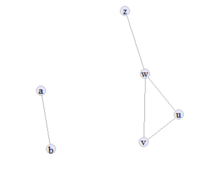

Example of a simple graph

So for example this graph has two components.

- Vertexes whose removal leads to more components are called **cutpoints**
- Edges whose removal leads to more components are calles **bridges**

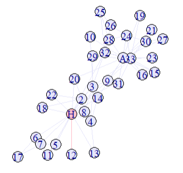

```r
data(karate)


# Cutpoints
articulation_points(karate)

V(karate)$color <- "lavender"

V(karate)[articulation.points(karate)]$color <- "pink"
plot(karate)

components(karate)
karate_split <- delete_vertices(karate, c(1))
plot(karate_split)
components(karate_split)


E(karate)$color <- "lavender"

##  Set bridge edges to red:
num_comp <- length(decompose(karate))
for (i in 1:length(E(karate))) {
  karate_sub <- delete_edges(karate, i)
  if ( length(decompose(karate_sub) ) > num_comp ) E(karate)$color[i] <- "pink"
}

plot(karate)
```

### k-connectivity

A network of size $n$ is called **k-connected** if $k < n$ and if it is connected even after removing any $k − 1$ nodes. So you need to remove $k$ nodes in order to disconnect the network.

- Every connected network is at least 1-connected: You need to remove at least one node to disconnect the network.
- If a network is $k$-connected, then the graph is also $(k - 1)$ connected: After removing $k -1$ nodes, it is still connected.
- *k-components* are the components a network is split into if you remove $k$ nodes and split it into more than one component.
  - *k-components* represent clique-like subgroups within a social network.
- The greatest integer $k$ such that the network is *k-connected* is known as the *vertex-connectivity κ*. If $K = 0$, the network is disconected.

A **cut set** of a network is the set of nodes whose removal disconnects the graph. A **minimum cut set** is a smallest cut set.

- Each minimum cut set contains $K$ elements
- A cutpoint exists if there is a minimum cut set of size $1$.

# Exercise

1. Create a Network with the following Adjacency Matrix:

$$M =
\begin{pmatrix}
0 & 1 & 0 & 1 & 0 & 1 \\
1 & 0 & 0 & 1 & 0 & 1 \\
0 & 0 & 0 & 1 & 0 & 1 \\
0 & 0 & 0 & 0 & 0 & 1 \\
0 & 1 & 0 & 1 & 0 & 1 \\
1 & 0 & 0 & 1 & 0 & 0
\end{pmatrix}$$

```r
M <- matrix(c(
  0, 1, 0, 1, 0, 1,
  1, 0, 0, 1, 0, 1,
  0, 0, 0, 1, 0, 1,
  0, 0, 0, 0, 0, 1,
  0, 1, 0, 1, 0, 1,
  1, 0, 0, 1, 0, 0
), nrow = 6, byrow = TRUE)


g <- graph_from_adjacency_matrix(M, mode = "directed")
plot(g)
```

2. How many edges and how many vertices has the network?

```r
vcount(g)
ecount(g)
```

3. Calculate the distances of node 3 to all other nodes. Interpret these values.

```r
dist <- distances(g, mode = "out")
dist
dist[3,]



#[1] 2 3 0 1 Inf 1 - the distance from node 3 to node 1 is 2, to node 2 its 3, there is a path of 0 to itself and no way to reach the vertex 5 (through out paths).
```

4. Find a command that gets you an edge list of the network.

```r
eg <- as_edgelist(g)
eg
```

5. Use the adjacency matrix to calculate the sum of outgoing and ingoing edges of node 6.

```r
sum(M[,6]==1) # ingoing edges
sum(M[6,]==1) # outgoing edges
```

6. Is there a tie between vertex 2 and vertex 3?

```r
are_adjacent(g, 2, 3)
```

7. Use the adjacency matrix to add an edge from vertex 5 to vertex 3.

```r
M2 <- matrix(c(
  0, 1, 0, 1, 0, 1,
  1, 0, 0, 1, 0, 1,
  0, 0, 0, 1, 0, 1,
  0, 0, 0, 0, 0, 1,
  0, 1, 1, 1, 0, 1,
  1, 0, 0, 1, 0, 0
), nrow = 6, byrow = TRUE)

g2 <- graph_from_adjacency_matrix(M2)
plot(g2)
```

8. Using the following dataframe, construct an adjacency matrix:

```r
df <- data.frame(id = c(1:10),
                 friend1 = c(9, 8, 10,  3,  1,  4,  2,  6,  7,  5), # first friend nomination
                 friend2 = c(5, 7, 2, 2, 3,  7,  3, 10,  1, 8),  # second friend nomination
                 friend3 = c(NA, NA, 4, 6, 10, 8, 5, NA, NA, 3), # third friend nomination
                 age = c(15, 15, 15, 16, 14, 14, 14, 15, 16, 14), # age in years
                 gender = c(2, 0, 1, 0, 1, 1, 2, 0, 0, 1)) # gender: 0= male, 1= female, 2= divers
```

7. Create a network from 6) and add the vertex attributes gender and age.

```r
edges1 <- data.frame(from = df$id,
                     to = df$friend1)

edges2 <- data.frame(from = df$id,
                     to = df$friend2)

edges3 <- data.frame(from  = df$id,
                     to = df$friend3)

# Combine all edges into one data frame
edges <- rbind(edges1, edges2, edges3)

# Remove rows with NA (where there was no third friend)
edges <- na.omit(edges)

# Create graph from edge list and vertex attributes
g <- graph_from_data_frame(d = edges, directed = TRUE, vertices = df)

plot(g)


# Set vertex attributes
V(g)$name <- df$id
V(g)$age <- df$age
V(g)$gender <- df$gender

scaled_age <- scales::rescale(V(g)$age, to = c(5, 20))

# Optional: plot the graph with attributes
plot(g,
     vertex.label = V(g)$name, # use "name" for labels
     vertex.size = scaled_age,
     vertex.color = ifelse(V(g)$gender == 0, "lightblue",
                    ifelse(V(g)$gender == 1, "pink", "purple")),
     edge.arrow.size = 0.5,
     main = "Friendship Network with Age and Gender")
```

# Data collection

There are many different forms of data collection for social network data. Options to collect data include Small Group questionnaires, large-scale Surveys, face-to-face observations, scraping of Websites, APIs or digital Archives. The choice of collection strategy has to be informed by the focus of research and available data sources. Almost always, when we are collecting network data, we are bounded by place and time where we have to make reasonable decisions in order to restrict our node set (Rawlings et al. 2023).

Collection strategies can broadly be structured in Local and Global collection strategies.

**Local (Egocentric Networks)**

- Focused around a particular node (**ego**).
- Provides insights into individual behavior and immediate social environment.
- Reduces challenges of defining network boundaries.
- **Limitations**:
  - Does not capture broader network structures.
  - Hard to infer global properties like paths, centrality, or clustering coefficients.

**Global (Sociocentric Networks)**

- Captures **all nodes and their relationships** within a specific setting (e.g., a school, company, or online platform).
- Allows measurement of **network-wide properties** (e.g., degree distribution, network diameter, clustering).
- **Limitations**:
  - **Data collection is expensive** and often requires complete participation.
  - **Boundary setting is crucial** to avoid biased conclusions.

Given the collection approach, there are different modes of collecting the data like the **Nominalist Approach**, which is based on observable links between actors

e.g.:

**Co-authorship networks** derived from Web of Science or Scopus.

- **Possible Biases**:
  - Over representation of English-language journals.
  - Exclusion of informal collaborations
  - Exclusion of fast and slow science

**Facebook-Connections**

- **Possible Biases**
  - Some individuals have significantly more interactions recorded due to higher usage (e.g., social media users with high posting frequency).
  - Group-Accounts

and the **Realist Approach**, which is based on self-reported relationships (e.g., surveys asking individuals to list friends).

- **Challenges**:
  - **Memory limitations** (people forget connections).
  - **Subjective definitions** of relationships (e.g., what constitutes a “friend”?).

## Missing data and imputation

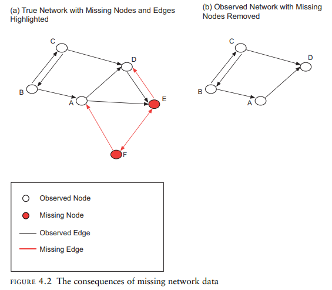

Consequences of hidden network data

Missing data in networks can bias results, particularly in global networks where completeness is crucial. Given the data collection choice and context, there can be different types of missing data:

- **Missing Nodes**: Some actors are absent due to nonresponse or other issues (e.g., students absent during a survey).
- **Missing Edges**: Some relationships are not captured (e.g., weak ties not reported).

Every form of data collection is prone to have some kinds of missing data, or inherent biases. Dealing with the possible consequences of the selected form of data collection and reporting possible biases and missings transparently is thus part of good scientific practice.

# Imputation Strategies

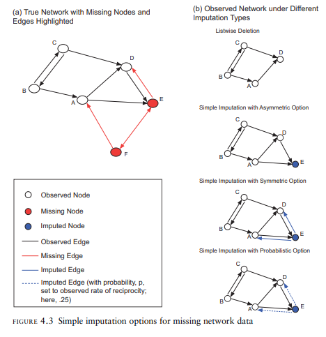

Imputation options

(Rawlings et al. 2023, 82)

- **Listwise Deletion**:
  - Removes missing nodes.
  - **Risk**: Can introduce bias, particularly if central nodes are missing.
- **Simple Imputation**:
  - Uses known information to fill gaps (e.g., adding a node if others mention it).
    - Asymetric
    - Symmetric
    - Probabilistic
- **Model-Based Imputation**:
  - Using **machine learning** or statistical models to infer missing ties.
  - Can incorporate attributes like race, gender, or past interactions.

## References

Csárdi, Gábor, Tamás Nepusz, Kirill Müller, Szabolcs Horvát, Vincent Traag, Fabio Zanini, and Daniel Noom. 2025. “Igraph for R: R Interface of the Igraph Library for Graph Theory and Network Analysis.” Zenodo. https://doi.org/10.5281/ZENODO.7682609.

Joshi, Vaidehi. 2017. “A Gentle Introduction To Graph Theory.” *Basecs*. https://medium.com/basecs/a-gentle-introduction-to-graph-theory-77969829ead8.

Lizardo, Omar, and Isaac Jilbert. 2023. “Social Networks: An Introduction.” *GitHub*. https://olizardo.github.io/networks-textbook/.

Rawlings, Craig M., Daniel A. McFarland, James Moody, and Jeffrey A. Smith, eds. 2023. “How Are Social Network Data Collected?” In *Network Analysis: Integrating Social Network Theory, Method, and Application with R*, 67–87. Structural Analysis in the Social Sciences. Cambridge: Cambridge University Press. https://doi.org/10.1017/9781139794985.005.

Wasserman, Stanley, and Katherine Faust. 2009. *Social Network Analysis: Methods and Applications*. 18. print. Structural Analysis in the Social Sciences 8. Cambridge: Cambridge Univ. Press.

Wilson, Robin J. 2009. *Introduction to Graph Theory*. 4. ed., [Nachdr.]. Harlow Munich: Prentice Hall.

## Copyright

© 2026 Leonie Steinbrinker